# R Notebook

## Try executing this chunk by clicking the *Run* button within the chunk or by placing your cursor inside it and pressing *Ctrl+Shift+Enter*.

```r
setwd("C:\\Users\\bethb\\OneDrive\\Desktop\\GitHub DataViz\\deliv2")
movieData <- read.csv("Best_Movie_by_Year_Netflix.csv")
```

```r
str(movieData, width=50, strict.width='cut')
```

```
'data.frame':   49 obs. of  6 variables:
 $ index          : int  0 1 2 3 4 5 6 7 8 9 ...
 $ TITLE          : chr  "White Christmas" "The"..
 $ RELEASE_YEAR   : int  1954 1961 1964 1967 197..
 $ SCORE          : num  7.5 7.5 7.8 7.7 7.7 8.1..
 $ MAIN_GENRE     : chr  "romance" "war" "drama"..
 $ MAIN_PRODUCTION: chr  "US" "US" "US" "US" ...
```

Cat-Cat relationships

While we use frequency tables in the univariate case, for the bivariate case (cat-cat) we prepare contingency tables. Let’s select a couple of categorical variables:

- Genre (genre of movies)
- Production (where movies were produced)

This contingency table shows counts for each combination of levels:

```r
(GenreProduction=table(movieData$MAIN_GENRE, movieData$MAIN_PRODUCTION))
```

```
              DE FR GB HK IN JP US
  action       0  0  0  0  1  0  0
  comedy       0  0  2  0  2  0  4
  crime        0  0  1  0  0  0  1
  documentary  0  0  1  0  0  0  0
  drama        1  1  1  1  4  0 14
  fantasy      0  0  0  0  1  0  0
  horror       0  0  0  0  0  0  2
  romance      0  0  0  0  0  0  3
  scifi        0  0  1  0  0  1  0
  thriller     0  0  0  0  2  0  3
  war          0  0  0  0  0  0  1
  western      0  0  0  0  0  0  1
```

When a table tries to hypothesize a relationship, you should have the independent variable in the columns, and the dependent one in the rows. Interpretation is difficult when you have counts so it is better to have percents. Percents should be computed by column to see how the levels of the dependent variable varies by each level of the independent one (reading along rows):

```r
# computing column percent from a contingency table
library(magrittr)
(GenProProp=prop.table(GenreProduction,
                       margin = 2)
  %>% round(.,3))
```

```
                 DE    FR    GB    HK    IN    JP    US
  action      0.000 0.000 0.000 0.000 0.100 0.000 0.000
  comedy      0.000 0.000 0.333 0.000 0.200 0.000 0.138
  crime       0.000 0.000 0.167 0.000 0.000 0.000 0.034
  documentary 0.000 0.000 0.167 0.000 0.000 0.000 0.000
  drama       1.000 1.000 0.167 1.000 0.400 0.000 0.483
  fantasy     0.000 0.000 0.000 0.000 0.100 0.000 0.000
  horror      0.000 0.000 0.000 0.000 0.000 0.000 0.069
  romance     0.000 0.000 0.000 0.000 0.000 0.000 0.103
  scifi       0.000 0.000 0.167 0.000 0.000 1.000 0.000
  thriller    0.000 0.000 0.000 0.000 0.200 0.000 0.103
  war         0.000 0.000 0.000 0.000 0.000 0.000 0.034
  western     0.000 0.000 0.000 0.000 0.000 0.000 0.034
```

The previous table shows you how the genre of movie is affected by the country of production. You need a plot that allows to highlight those differences across countries. As before, we turn it into a data frame

```r
# making a data frame from a contingency table
(GenProDF = as.data.frame(GenreProduction))
```

| Var1 | Var2 | Freq |
| --- | --- | --- |
| action | DE | 0 |
| comedy | DE | 0 |
| crime | DE | 0 |
| documentary | DE | 0 |
| drama | DE | 1 |
| fantasy | DE | 0 |
| horror | DE | 0 |
| romance | DE | 0 |
| scifi | DE | 0 |
| thriller | DE | 0 |

[output cut: 74 more lines]

We also have the table with marginal percents by column

```r
as.data.frame(GenProProp)
```

| Var1 | Var2 | Freq |
| --- | --- | --- |
| action | DE | 0.000 |
| comedy | DE | 0.000 |
| crime | DE | 0.000 |
| documentary | DE | 0.000 |
| drama | DE | 1.000 |
| fantasy | DE | 0.000 |
| horror | DE | 0.000 |
| romance | DE | 0.000 |
| scifi | DE | 0.000 |
| thriller | DE | 0.000 |

[output cut: 74 more lines]

We should simply add the last column to the data frame of counts

```r
GenProDF$Share=as.data.frame(GenProProp)[,3]
GenProDF
```

| Var1 | Var2 | Freq | Share |
| --- | --- | --- | --- |
| action | DE | 0 | 0.000 |
| comedy | DE | 0 | 0.000 |
| crime | DE | 0 | 0.000 |
| documentary | DE | 0 | 0.000 |
| drama | DE | 1 | 1.000 |
| fantasy | DE | 0 | 0.000 |
| horror | DE | 0 | 0.000 |
| romance | DE | 0 | 0.000 |
| scifi | DE | 0 | 0.000 |
| thriller | DE | 0 | 0.000 |

[output cut: 74 more lines]

We can change the names of the previous data frame

```r
names(GenProDF)[1:3]=c("Genre","Country","Counts")
#then
GenProDF
```

| Genre | Country | Counts | Share |
| --- | --- | --- | --- |
| action | DE | 0 | 0.000 |
| comedy | DE | 0 | 0.000 |
| crime | DE | 0 | 0.000 |
| documentary | DE | 0 | 0.000 |
| drama | DE | 1 | 1.000 |
| fantasy | DE | 0 | 0.000 |
| horror | DE | 0 | 0.000 |
| romance | DE | 0 | 0.000 |
| scifi | DE | 0 | 0.000 |
| thriller | DE | 0 | 0.000 |

[output cut: 74 more lines]

use ggplot to represent the contingency table

```r
library(ggplot2)
base1 = ggplot(data = GenProDF,
               aes(x = Country,
                   y = Share,
                   fill = Genre))
```

Then play with some bar positions

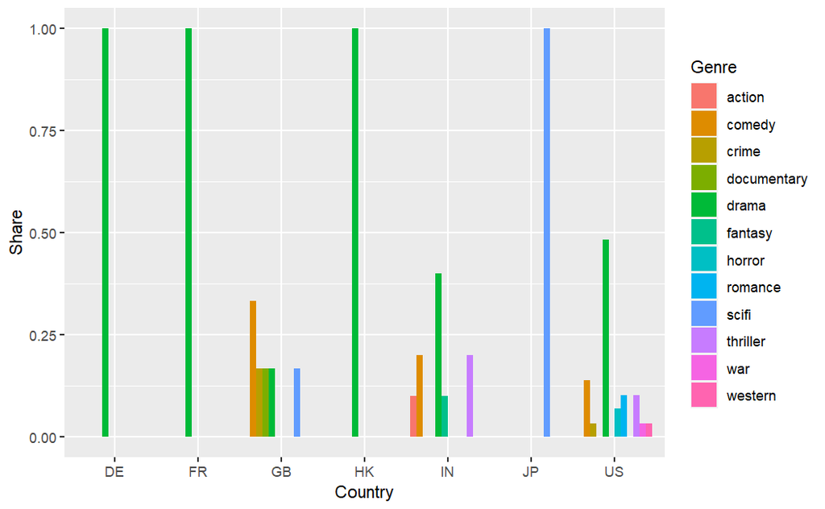

```r
barDodge = base1 + geom_bar(stat="identity",
                            position='dodge')
barDodge
```

second is a stack style

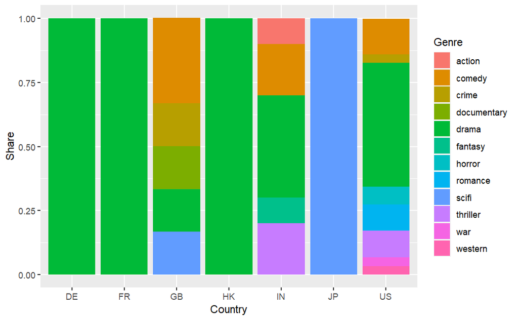

```r
barStacked = base1 + geom_bar(stat="identity",
                              position = 'stack') #default
barStacked
```

stacked will work better whne there are more than two bars on a dodge plot

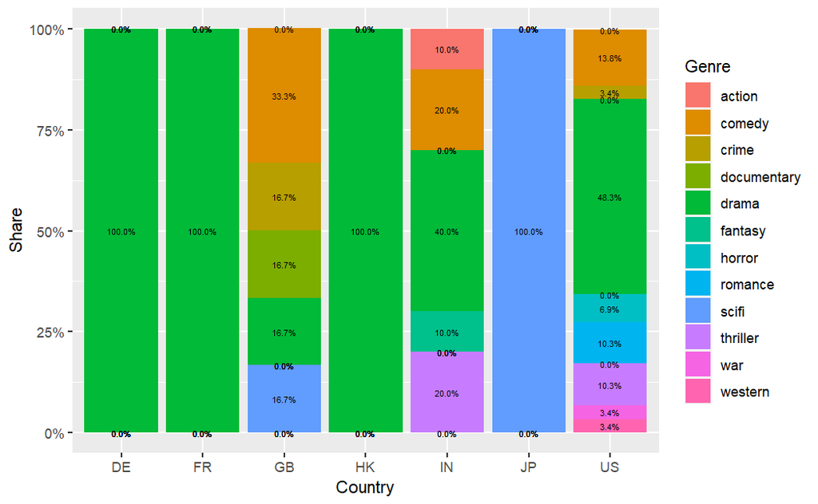

```r
library(scales)
#annotating
barStackedAnn = barStacked + geom_text(size = 2, position = position_stack(vjust = 0.5), #center
                                       aes(label = percent(Share,accurary = 0.1))) #percent format
barStackedAnn = barStackedAnn + scale_y_continuous(labels = percent)
barStackedAnn
```

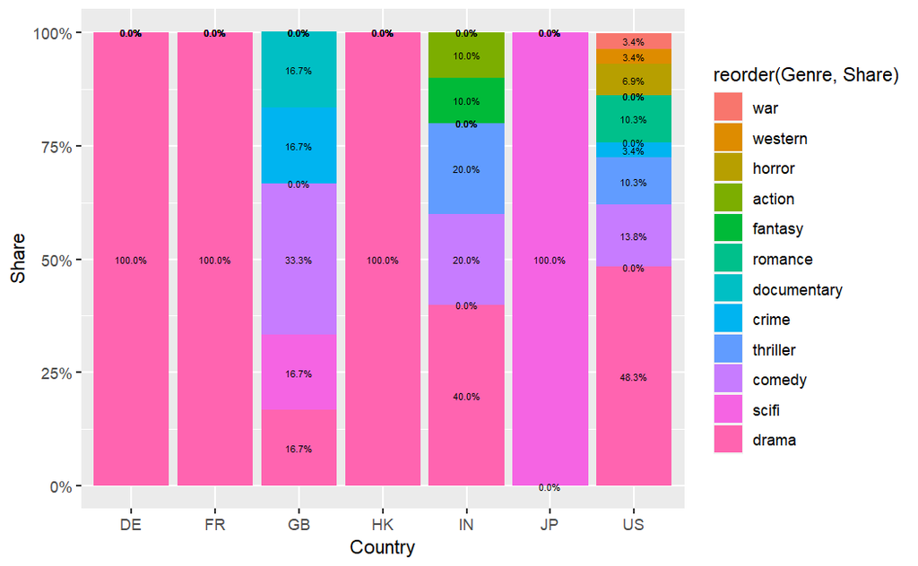

```r
base1 = ggplot(data = GenProDF,
               aes(x = Country, y = Share,
                   fill = reorder(Genre,Share))) # reordering

barStacked = base1 + geom_bar(stat = "identity", position = 'stack')
barStacked = barStacked + geom_text(size = 2,
                                    position = position_stack(vjust=0.5), aes(label=percent(Share,accuracy=0.1)))
barStacked = barStacked + scale_y_continuous(labels = percent)
barStacked
```

use a barplot with facets with bars dodged

```r
# base with only X and Y in 'aes()'
GenProDF = as.data.frame(GenreProduction)
#marginal
GenProProp = prop.table(GenreProduction,margin=2)
#renaming
names(GenProDF)=c("Genre","Country","Counts")
# adding marginal
GenProDF$Share=as.data.frame(GenProProp)[,3]
# result for ggplot
head(GenProDF,20)
```

|  | Genre | Country | Counts | Share |
| --- | --- | --- | --- | --- |
| 1 | action | DE | 0 | 0 |
| 2 | comedy | DE | 0 | 0 |
| 3 | crime | DE | 0 | 0 |
| 4 | documentary | DE | 0 | 0 |
| 5 | drama | DE | 1 | 1 |
| 6 | fantasy | DE | 0 | 0 |
| 7 | horror | DE | 0 | 0 |
| 8 | romance | DE | 0 | 0 |
| 9 | scifi | DE | 0 | 0 |
| 10 | thriller | DE | 0 | 0 |

[output cut: 10 more lines]

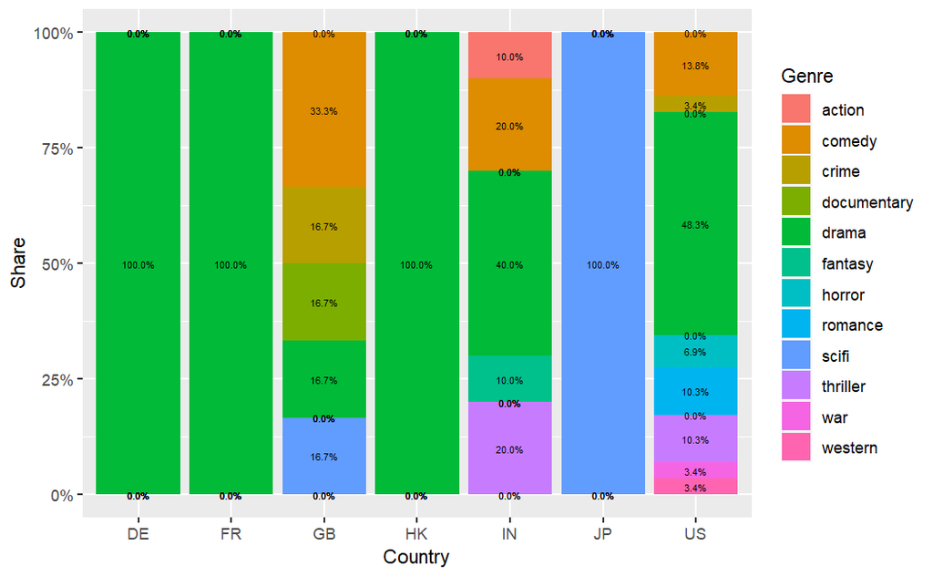

```r
base2 = ggplot(data=GenProDF,
               aes(x = Country,y = Share, fill = Genre))
base2 = base2 + geom_bar(stat = "identity", position = 'fill') + geom_text(size = 2,
                                                                           position = position_stack(vjust = 0.5),
                                                                           aes(label=percent(Share,accuracy=0.1)))
barStacked2 = base2 + scale_y_continuous(labels = percent)
barStacked2
```

This plot will need a lot of work, so using it may not be a good strategy

First option you can use a barplot with facets

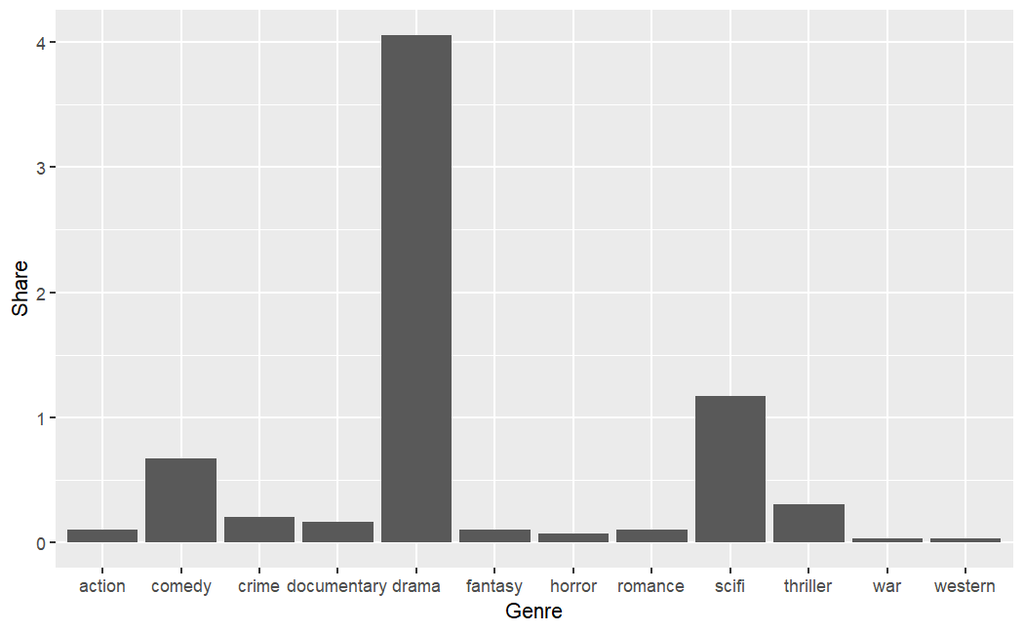

```r
#base with only x and y in aes()
barBar = ggplot(GenProDF, aes(x = Genre, y = Share))

# the bars
barPlot = barBar + geom_bar(stat = "identity")
barPlot
```

now lets see the facets

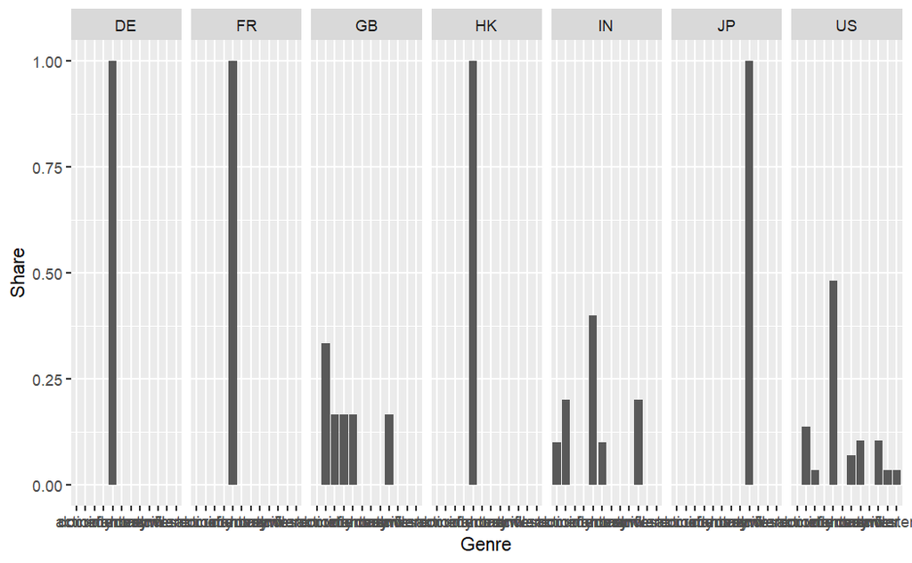

```r
# bar per country with 'facet'
barsFt = barPlot + facet_grid(~ Country)

barsFt
```

This does not look like the crosstable yet; let’s solve that

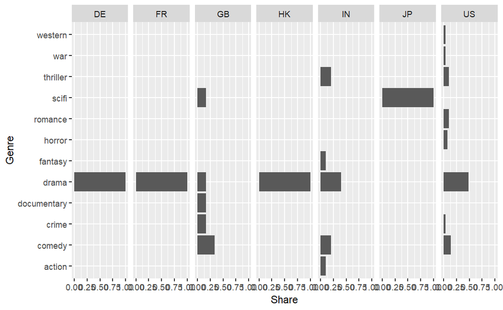

```r
barsFt + coord_flip()
```

Then we can reorder the bars:

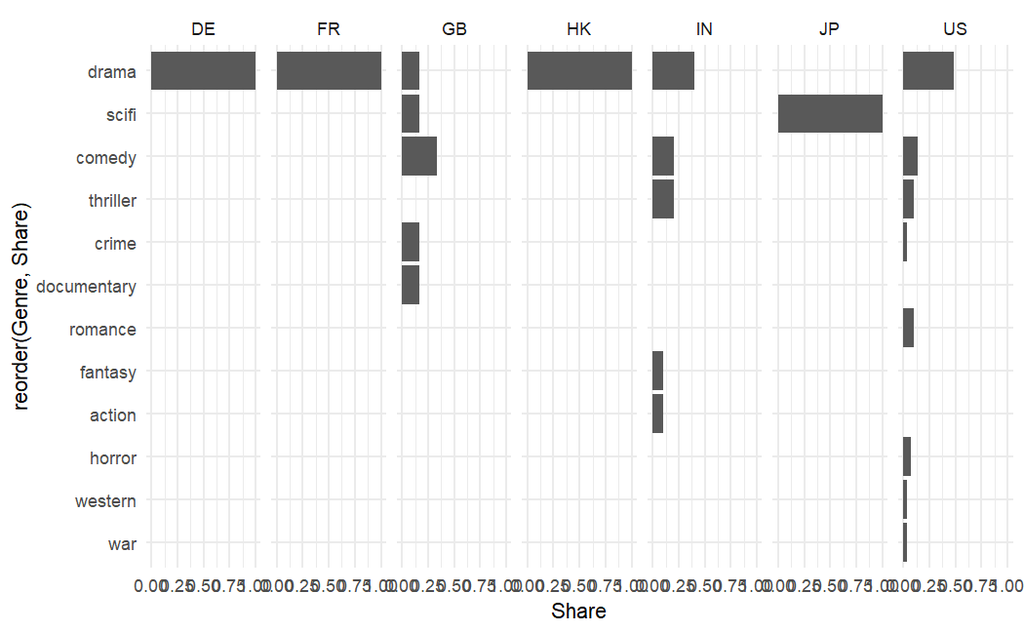

```r
# new base
baseRE = ggplot(GenProDF,
                aes(x = reorder(Genre, Share),
                    y = Share)) + theme_minimal()

barPlotRE = baseRE + geom_bar(stat = "identity")
barFtRE = barPlotRE + facet_grid(~ Country)
barFtRE = barFtRE + coord_flip()

barFtRE
```

let’s work on the Genre labels

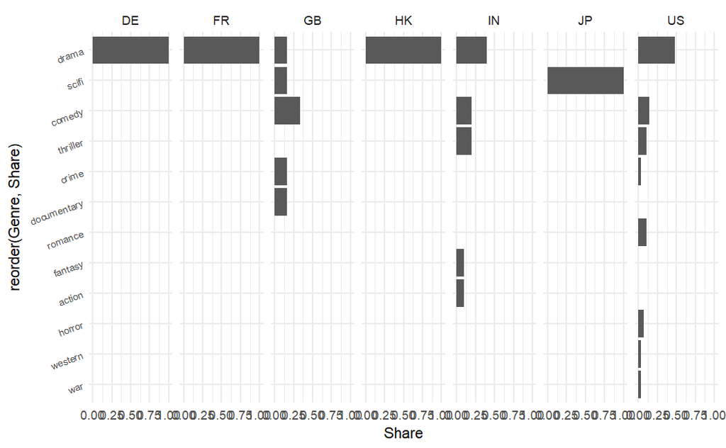

```r
barFtRE = barFtRE + theme(axis.text.y=element_text(size=7,angle=20))
barFtRE
```

Would you annotate the bars:

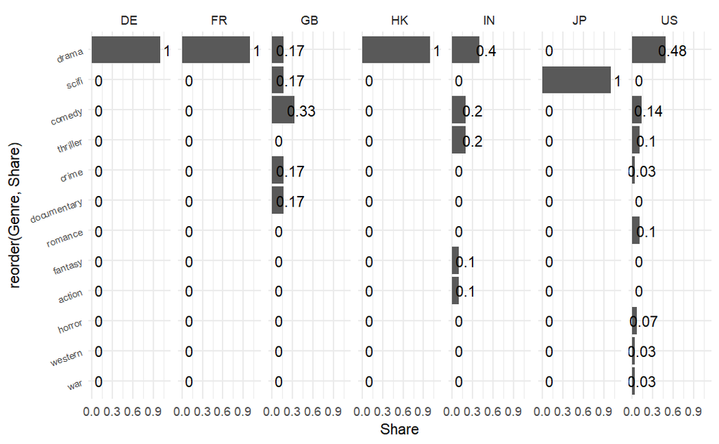

```r
barREann=barFtRE + geom_text(aes(label=round(Share,2)),
                             nudge_y=0.1)
barREann
```

let’s annotate conditionally instead

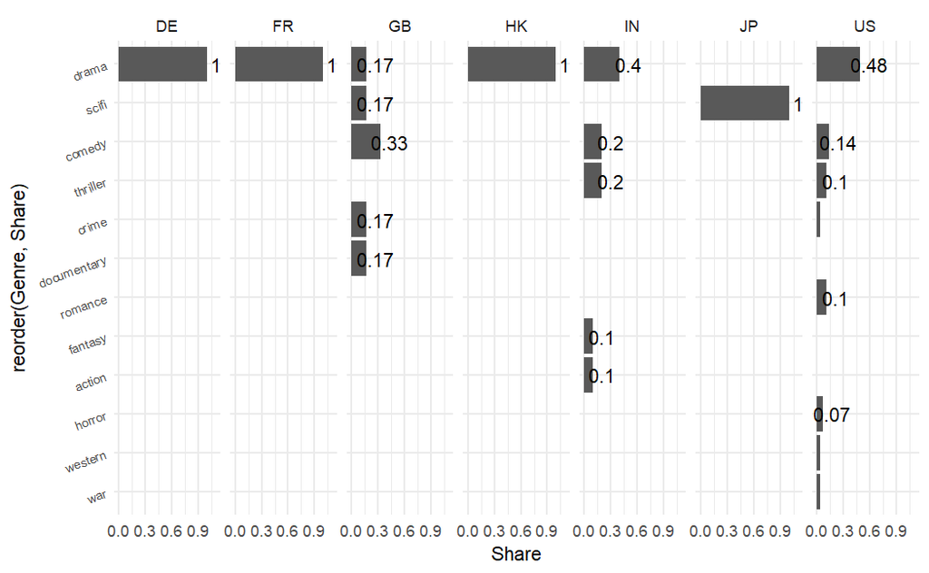

```r
barCond = barFtRE + geom_text(aes(label = ifelse(Share>0.05, #condition to annotate
                                                 round(Share,2),"")),
                              nudge_y = 0.1)
barCond
```

What about percents instead

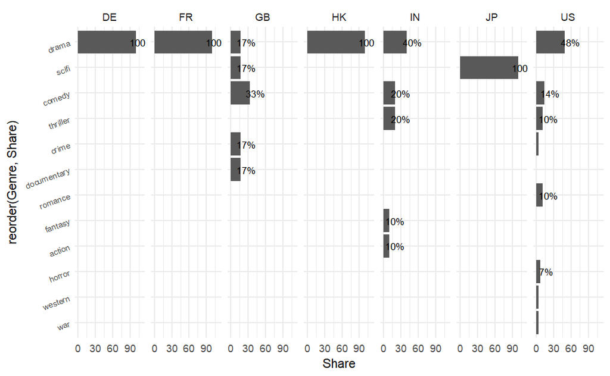

```r
barFtRE + geom_text(aes(label=ifelse(Share > 0.05,
                                     percent(Share,accuracy=1), "")),
                    nudge_y = 0.1,size=3) + scale_y_continuous(labels=percent_format(accuracy = 1,suffix=""))
```

Tabular data - Bivariate relationship 2: Categorical - Numerical

```r
# score report
# notice the spread of values
summary(movieData$SCORE)
```

```
   Min. 1st Qu.  Median    Mean 3rd Qu.    Max.
  5.800   7.500   8.100   7.871   8.300   9.000
```

```r
movieData[which.max(movieData$SCORE),]
```

|  | index | TITLE | RELEASE_YEAR | SCORE | MAIN_GENRE | MAIN_PRODUCTION |
| --- | --- | --- | --- | --- | --- | --- |
| 47 | 46 | David Attenborough: A Life on Our Planet | 2020 | 9 | documentary | GB |

Let’s get the median for each Country

```r
ScoreCountry=movieData[complete.cases(movieData),]
aggregate(data = ScoreCountry, SCORE~MAIN_PRODUCTION,median)
```

| MAIN_PRODUCTION | SCORE |
| --- | --- |
| DE | 7.20 |
| FR | 7.30 |
| GB | 8.25 |
| HK | 8.00 |
| IN | 8.20 |
| JP | 8.00 |
| US | 7.70 |

Let’s request a boxplot for each country

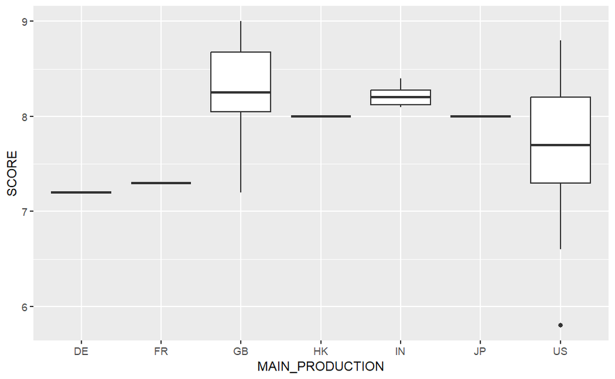

```r
# boxplot of score per country

library(ggplot2)
base=ggplot(data = ScoreCountry,
            aes(x = MAIN_PRODUCTION, y=SCORE))

base + geom_boxplot()
```

let’s check out the statistics behind the median

```r
# using summary function
tapply(ScoreCountry$SCORE,
       ScoreCountry$MAIN_PRODUCTION, summary)
```

```
$DE
   Min. 1st Qu.  Median    Mean 3rd Qu.    Max.
    7.2     7.2     7.2     7.2     7.2     7.2

$FR
   Min. 1st Qu.  Median    Mean 3rd Qu.    Max.
    7.3     7.3     7.3     7.3     7.3     7.3

$GB
   Min. 1st Qu.  Median    Mean 3rd Qu.    Max.
  7.200   8.050   8.250   8.250   8.675   9.000

$HK
   Min. 1st Qu.  Median    Mean 3rd Qu.    Max.
      8       8       8       8       8       8

$IN
   Min. 1st Qu.  Median    Mean 3rd Qu.    Max.
  8.100   8.125   8.200   8.220   8.275   8.400

$JP
   Min. 1st Qu.  Median    Mean 3rd Qu.    Max.
      8       8       8       8       8       8

$US
   Min. 1st Qu.  Median    Mean 3rd Qu.    Max.
  5.800   7.300   7.700   7.707   8.200   8.800
```

If we consider the situation of score > 7 is expected behavior, let me keep the ones that are > 7 using ggarrange

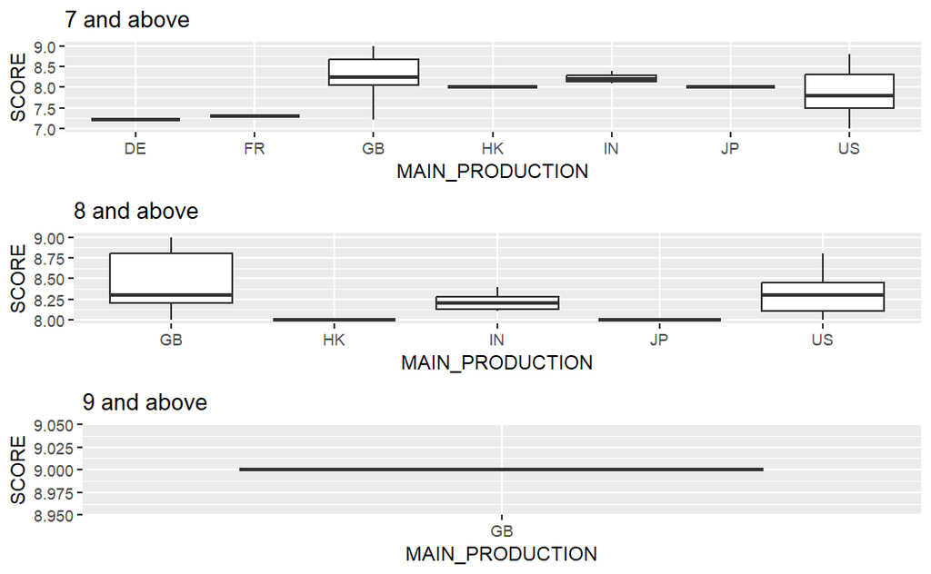

```r
library(ggpubr)

base7 = ggplot(data = ScoreCountry[ScoreCountry$SCORE >= 7,],
               aes(x=MAIN_PRODUCTION, y=SCORE))
box7 = base7 + geom_boxplot() + labs(title = "7 and above")

base8 = ggplot(data = ScoreCountry[ScoreCountry$SCORE >= 8,],
               aes(x = MAIN_PRODUCTION, y = SCORE))
box8 = base8 + geom_boxplot() + labs(title = "8 and above")

base9 = ggplot(data = ScoreCountry[ScoreCountry$SCORE >= 9,],
               aes(x = MAIN_PRODUCTION, y = SCORE))
box9 = base9 + geom_boxplot() + labs(title = "9 and above")

# all in one
ggarrange(box7, box8, box9, ncol=1)
```

```r
ScoreAbove7 = ScoreCountry[ScoreCountry$SCORE >= 7,]
```

Let’s see if flipping helps you see better

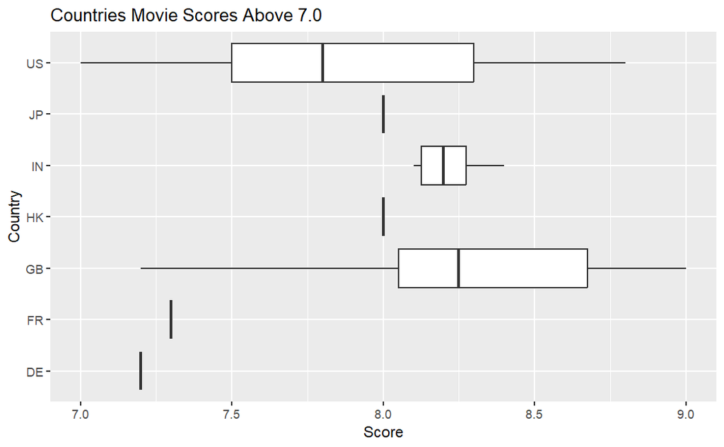

```r
titleText = "Countries Movie Scores Above 7.0"

names(ScoreAbove7)=c("Index","Title","Release Year", "Score", "Genre", "Country")
baseSA7 = ggplot(data = ScoreAbove7,
                 aes(x = Country,
                     y = Score))

boxSA7 = baseSA7 + geom_boxplot() + labs(title = titleText)

boxSA7 + coord_flip()
```

Let’s reorder the category by median of the numeric variable

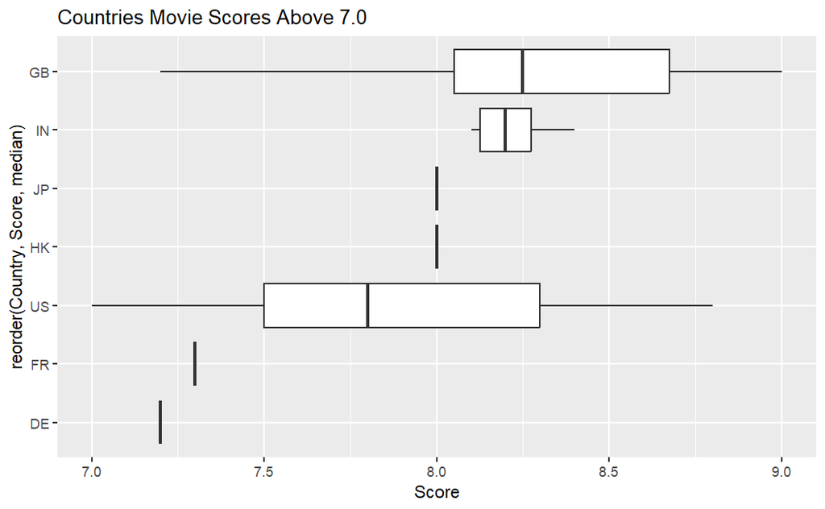

```r
baseSA7 = ggplot(data = ScoreAbove7,
                 aes(x = reorder(Country, Score, median),
                     y = Score))
boxSA7 = baseSA7 + geom_boxplot() + labs(title = titleText)

# flipping
boxSA7 + coord_flip()
```

What if we use the histogram:

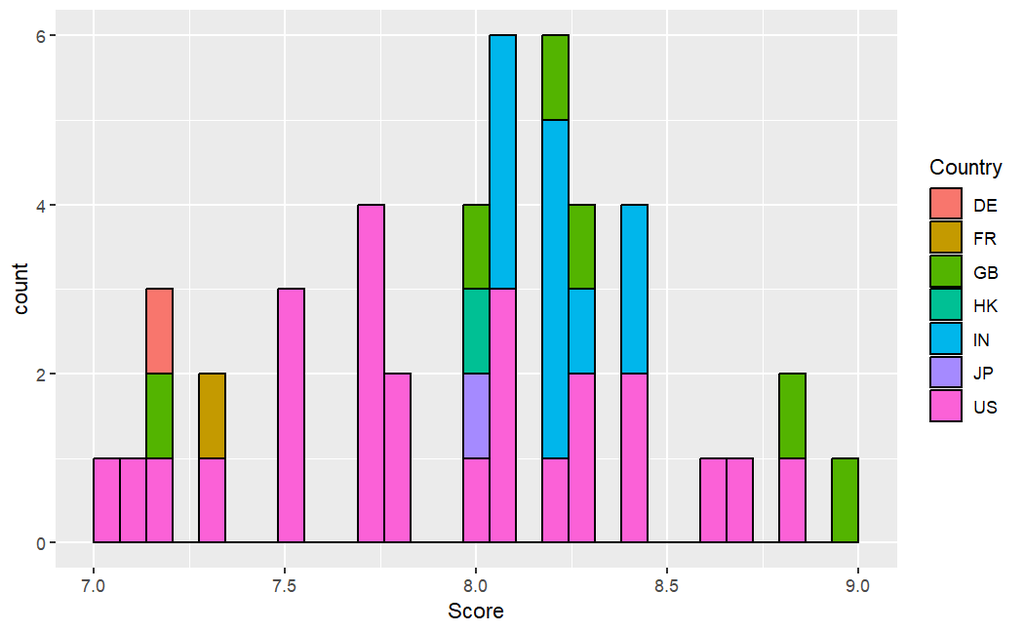

```r
baseHistSA7 = ggplot(data = ScoreAbove7,
                     aes(x = Score))
HistSA7 = baseHistSA7 + geom_histogram(aes(fill=Country),
                                       color = 'black') # color the border
HistSA7
```

You need facets:

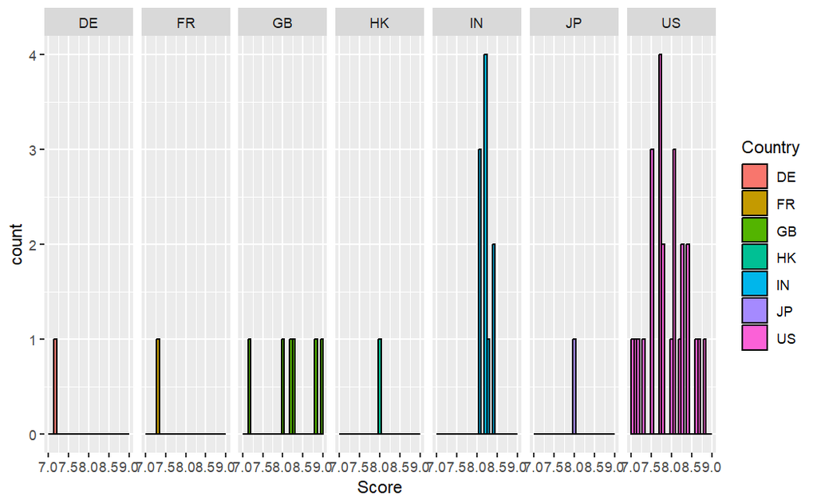

```r
HistSA7 + facet_grid(~Country)
```

The alternative without legend

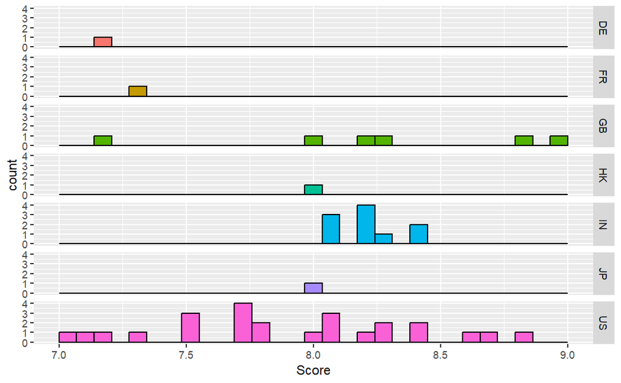

```r
HistSA7 + facet_grid(Country~.) + guides(fill="none")
```

What about reordering

```r
                            # Replicate data
movieDataNew$CountryGroup <- factor(movieDataNew$CountryGroup,      # Reordering group factor levels
                         levels = c("US", "IN", "GB", "HK", "JP", "FR", "DE"))
```

[output not shown]

[figure not shown]

```r
titleText2 = "Which Countries Produced the Highest Rated Netflix Movies?"
HistSA7.1 = HistSA7 + labs(title = titleText2)
HistSA7.1
```

[figure not shown]

```r
sourceText = 'Source: Eduardo Gonzalez'
HistSA7.2 = ggplot(transform(ScoreCountry,
                 CountryH=factor(MAIN_PRODUCTION, levels = c("US", "IN", "GB", "HK", "JP", "FR", "DE")))) + geom_histogram(aes(SCORE), fill='darkgreen')+facet_grid(CountryH~.)

HistSA7.3 = HistSA7.2 + labs(title = titleText2, x = "movie score", y = "number of movies per score", caption = c('Source: Eduardo Gonzalez','Countries: United States, India, Great Britain, Hong Kong, Japan, France, Denmark'))

HistSA7.4 = HistSA7.3 + theme(axis.text.y = element_text(angle = 90,
                                   hjust = 1,
                                   size = 5)) +  theme(plot.caption = element_text(hjust=c(0,1), size = 6),plot.title = element_text(hjust=0.5))
HistSA7.4
```

```r
NA
NA
```

- notes from Prof. Magallenes,
- reorder by variance and mean score
- annotate what I’m trying to say